# Supervised Learning - Foundations Project: ReCell

## Problem Statement

### Business Context

Buying and selling used phones and tablets used to be something that happened on a handful of online marketplace sites. But the used and refurbished device market has grown considerably over the past decade, and a new IDC (International Data Corporation) forecast predicts that the used phone market would be worth \$52.7bn by 2023 with a compound annual growth rate (CAGR) of 13.6% from 2018 to 2023. This growth can be attributed to an uptick in demand for used phones and tablets that offer considerable savings compared with new models.

Refurbished and used devices continue to provide cost-effective alternatives to both consumers and businesses that are looking to save money when purchasing one. There are plenty of other benefits associated with the used device market. Used and refurbished devices can be sold with warranties and can also be insured with proof of purchase. Third-party vendors/platforms, such as Verizon, Amazon, etc., provide attractive offers to customers for refurbished devices. Maximizing the longevity of devices through second-hand trade also reduces their environmental impact and helps in recycling and reducing waste. The impact of the COVID-19 outbreak may further boost this segment as consumers cut back on discretionary spending and buy phones and tablets only for immediate needs.

### Objective

The rising potential of this comparatively under-the-radar market fuels the need for an ML-based solution to develop a dynamic pricing strategy for used and refurbished devices. ReCell, a startup aiming to tap the potential in this market, has hired you as a data scientist. They want you to analyze the data provided and build a linear regression model to predict the price of a used phone/tablet and identify factors that significantly influence it.

### Data Description

The data contains the different attributes of used/refurbished phones and tablets. The data was collected in the year 2021. The detailed data dictionary is given below.

- brand_name: Name of manufacturing brand
- os: OS on which the device runs
- screen_size: Size of the screen in cm
- 4g: Whether 4G is available or not
- 5g: Whether 5G is available or not
- main_camera_mp: Resolution of the rear camera in megapixels
- selfie_camera_mp: Resolution of the front camera in megapixels
- int_memory: Amount of internal memory (ROM) in GB
- ram: Amount of RAM in GB
- battery: Energy capacity of the device battery in mAh
- weight: Weight of the device in grams
- release_year: Year when the device model was released
- days_used: Number of days the used/refurbished device has been used
- normalized_new_price: Normalized price of a new device of the same model in euros
- normalized_used_price: Normalized price of the used/refurbished device in euros

## Importing necessary libraries

```python
# Libraries to help with reading and manipulating data
import numpy as np
import pandas as pd
# Libraries to help with data visualization
import matplotlib.pyplot as plt
import seaborn as sns
%matplotlib inline
# Library for randomized data splitting into train and test sets
from sklearn.model_selection import train_test_split
# Library to build linear regression model
import statsmodels.api as sm
# Library to checkmodel performance
from sklearn.metrics import mean_absolute_error, mean_squared_error, r2_score
# Library to calculate the variance inflation factor
from statsmodels.stats.outliers_influence import variance_inflation_factor
```

## Loading the dataset

```python
from google.colab import drive
drive.mount('/content/drive')
```

Read the csv file

```python
data = pd.read_csv('/content/drive/My Drive/PGDSBA/used_device_data.csv')
```

We create a copy of the original dataframe. This will be our working copy.

```python
df = data.copy()
```

## Data Overview

- Observations
- Sanity checks

```python
df.head() #displays the first 5 rows of dataframe
```

|  | brand_name | os | screen_size | 4g | 5g | main_camera_mp | selfie_camera_mp | int_memory | ram | battery | weight | release_year | days_used | normalized_used_price | normalized_new_price |
| --- | --- | --- | --- | --- | --- | --- | --- | --- | --- | --- | --- | --- | --- | --- | --- |
| 0 | Honor | Android | 14.50 | yes | no | 13.0 | 5.0 | 64.0 | 3.0 | 3020.0 | 146.0 | 2020 | 127 | 4.307572 | 4.715100 |
| 1 | Honor | Android | 17.30 | yes | yes | 13.0 | 16.0 | 128.0 | 8.0 | 4300.0 | 213.0 | 2020 | 325 | 5.162097 | 5.519018 |
| 2 | Honor | Android | 16.69 | yes | yes | 13.0 | 8.0 | 128.0 | 8.0 | 4200.0 | 213.0 | 2020 | 162 | 5.111084 | 5.884631 |
| 3 | Honor | Android | 25.50 | yes | yes | 13.0 | 8.0 | 64.0 | 6.0 | 7250.0 | 480.0 | 2020 | 345 | 5.135387 | 5.630961 |
| 4 | Honor | Android | 15.32 | yes | no | 13.0 | 8.0 | 64.0 | 3.0 | 5000.0 | 185.0 | 2020 | 293 | 4.389995 | 4.947837 |

```python
df.tail() #displays the last 5 rows of dataframe
```

|  | brand_name | os | screen_size | 4g | 5g | main_camera_mp | selfie_camera_mp | int_memory | ram | battery | weight | release_year | days_used | normalized_used_price | normalized_new_price |
| --- | --- | --- | --- | --- | --- | --- | --- | --- | --- | --- | --- | --- | --- | --- | --- |
| 3449 | Asus | Android | 15.34 | yes | no | NaN | 8.0 | 64.0 | 6.0 | 5000.0 | 190.0 | 2019 | 232 | 4.492337 | 6.483872 |
| 3450 | Asus | Android | 15.24 | yes | no | 13.0 | 8.0 | 128.0 | 8.0 | 4000.0 | 200.0 | 2018 | 541 | 5.037732 | 6.251538 |
| 3451 | Alcatel | Android | 15.80 | yes | no | 13.0 | 5.0 | 32.0 | 3.0 | 4000.0 | 165.0 | 2020 | 201 | 4.357350 | 4.528829 |
| 3452 | Alcatel | Android | 15.80 | yes | no | 13.0 | 5.0 | 32.0 | 2.0 | 4000.0 | 160.0 | 2020 | 149 | 4.349762 | 4.624188 |
| 3453 | Alcatel | Android | 12.83 | yes | no | 13.0 | 5.0 | 16.0 | 2.0 | 4000.0 | 168.0 | 2020 | 176 | 4.132122 | 4.279994 |

From df.head() and df.tail(), we see that the dataframe is loaded properly.

```python
df.shape #displays the (number of rows, number of columns) in the dataframe
```

```
(3454, 15)
```

There are 3454 rows and 15 columns in the dataframe.

```python
df.info() #displays the datatypes of the columns in the dataframe
```

```
<class 'pandas.core.frame.DataFrame'>
RangeIndex: 3454 entries, 0 to 3453
Data columns (total 15 columns):
 #   Column                 Non-Null Count  Dtype
---  ------                 --------------  -----
 0   brand_name             3454 non-null   object
 1   os                     3454 non-null   object
 2   screen_size            3454 non-null   float64
 3   4g                     3454 non-null   object
 4   5g                     3454 non-null   object
 5   main_camera_mp         3275 non-null   float64
 6   selfie_camera_mp       3452 non-null   float64
 7   int_memory             3450 non-null   float64
 8   ram                    3450 non-null   float64
 9   battery                3448 non-null   float64
 10  weight                 3447 non-null   float64
 11  release_year           3454 non-null   int64
 12  days_used              3454 non-null   int64
 13  normalized_used_price  3454 non-null   float64
 14  normalized_new_price   3454 non-null   float64
dtypes: float64(9), int64(2), object(4)
memory usage: 404.9+ KB
```

- There are 11 numerical type columns and 4 categorical type columns.
- `release_year` and `days_used` are of int64 datatype.
- `screen_size`, `main_camera_mp`, `selfie_camera_mp`, `int_memory`, `ram`, `battery`, `weight`, `normalized_new_price` and `normalized_used_price` are of float64 datatype.
- `brand_name`, `os`, `4g` and `5g` are of object datatype.

```python
df.describe(include='all').T #displays the statistical summary of the dataframe
```

|  | count | unique | top | freq | mean | std | min | 25% | 50% | 75% | max |
| --- | --- | --- | --- | --- | --- | --- | --- | --- | --- | --- | --- |
| brand_name | 3454 | 34 | Others | 502 | NaN | NaN | NaN | NaN | NaN | NaN | NaN |
| os | 3454 | 4 | Android | 3214 | NaN | NaN | NaN | NaN | NaN | NaN | NaN |
| screen_size | 3454.0 | NaN | NaN | NaN | 13.713115 | 3.80528 | 5.08 | 12.7 | 12.83 | 15.34 | 30.71 |
| 4g | 3454 | 2 | yes | 2335 | NaN | NaN | NaN | NaN | NaN | NaN | NaN |
| 5g | 3454 | 2 | no | 3302 | NaN | NaN | NaN | NaN | NaN | NaN | NaN |
| main_camera_mp | 3275.0 | NaN | NaN | NaN | 9.460208 | 4.815461 | 0.08 | 5.0 | 8.0 | 13.0 | 48.0 |
| selfie_camera_mp | 3452.0 | NaN | NaN | NaN | 6.554229 | 6.970372 | 0.0 | 2.0 | 5.0 | 8.0 | 32.0 |
| int_memory | 3450.0 | NaN | NaN | NaN | 54.573099 | 84.972371 | 0.01 | 16.0 | 32.0 | 64.0 | 1024.0 |
| ram | 3450.0 | NaN | NaN | NaN | 4.036122 | 1.365105 | 0.02 | 4.0 | 4.0 | 4.0 | 12.0 |
| battery | 3448.0 | NaN | NaN | NaN | 3133.402697 | 1299.682844 | 500.0 | 2100.0 | 3000.0 | 4000.0 | 9720.0 |
| weight | 3447.0 | NaN | NaN | NaN | 182.751871 | 88.413228 | 69.0 | 142.0 | 160.0 | 185.0 | 855.0 |
| release_year | 3454.0 | NaN | NaN | NaN | 2015.965258 | 2.298455 | 2013.0 | 2014.0 | 2015.5 | 2018.0 | 2020.0 |
| days_used | 3454.0 | NaN | NaN | NaN | 674.869716 | 248.580166 | 91.0 | 533.5 | 690.5 | 868.75 | 1094.0 |
| normalized_used_price | 3454.0 | NaN | NaN | NaN | 4.364712 | 0.588914 | 1.536867 | 4.033931 | 4.405133 | 4.7557 | 6.619433 |
| normalized_new_price | 3454.0 | NaN | NaN | NaN | 5.233107 | 0.683637 | 2.901422 | 4.790342 | 5.245892 | 5.673718 | 7.847841 |

```python
df.isnull().sum() #displays the number of missing values in each column of the dataframe
```

```
brand_name                 0
os                         0
screen_size                0
4g                         0
5g                         0
main_camera_mp           179
selfie_camera_mp           2
int_memory                 4
ram                        4
battery                    6
weight                     7
release_year               0
days_used                  0
normalized_used_price      0
normalized_new_price       0
dtype: int64
```

179 values from `main_camera_mp`, 2 from `selfie_camera_mp`, 4 each from `int_memory` and `ram`, 6 from `battery` and 7 from `weight` are missing.

```python
df.duplicated().sum()
```

```
0
```

There are no duplicates in the dataframe.

## Exploratory Data Analysis (EDA)

- EDA is an important part of any project involving data.
- It is important to investigate and understand the data better before building a model with it.
- A few questions have been mentioned below which will help you approach the analysis in the right manner and generate insights from the data.
- A thorough analysis of the data, in addition to the questions mentioned below, should be done.

**Questions**:

1. What does the distribution of normalized used device prices look like?
2. What percentage of the used device market is dominated by Android devices?
3. The amount of RAM is important for the smooth functioning of a device. How does the amount of RAM vary with the brand?
4. A large battery often increases a device's weight, making it feel uncomfortable in the hands. How does the weight vary for phones and tablets offering large batteries (more than 4500 mAh)?
5. Bigger screens are desirable for entertainment purposes as they offer a better viewing experience. How many phones and tablets are available across different brands with a screen size larger than 6 inches?
6. A lot of devices nowadays offer great selfie cameras, allowing us to capture our favorite moments with loved ones. What is the distribution of devices offering greater than 8MP selfie cameras across brands?
7. Which attributes are highly correlated with the normalized price of a used device?

### Univariate Analysis

1. Analysing the manufacturing brand

```python
df['brand_name'].unique()
```

```
array(['Honor', 'Others', 'HTC', 'Huawei', 'Infinix', 'Lava', 'Lenovo',
       'LG', 'Meizu', 'Micromax', 'Motorola', 'Nokia', 'OnePlus', 'Oppo',
       'Realme', 'Samsung', 'Vivo', 'Xiaomi', 'ZTE', 'Apple', 'Asus',
       'Coolpad', 'Acer', 'Alcatel', 'BlackBerry', 'Celkon', 'Gionee',
       'Google', 'Karbonn', 'Microsoft', 'Panasonic', 'Sony', 'Spice',
       'XOLO'], dtype=object)
```

```python
df['brand_name'].nunique()
```

```
34
```

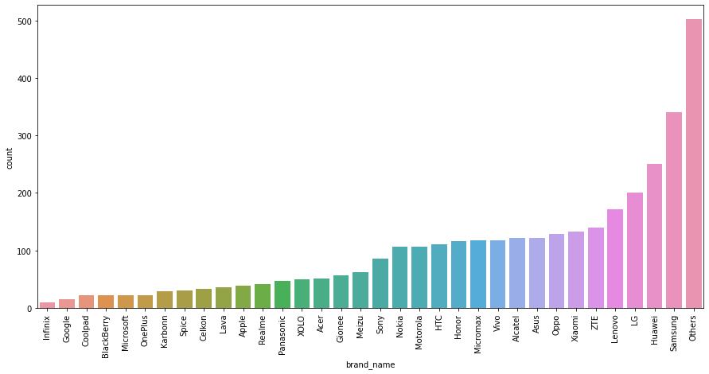

```python
plt.figure(figsize=[15,7])
plt.xticks(rotation = 90)
sns.countplot(data=df, x=df['brand_name'], order=df['brand_name'].value_counts(ascending=True).index);
plt.show()
```

- The dataframe contains data for 34 manufacturing brands.
- Others category has the maximum count, followed by Samsung and Huawei.
- Infinix has the lowest count, followed by Google.
1. Analysing the OS on which the device runs

```python
df['os'].unique()
```

```
array(['Android', 'Others', 'iOS', 'Windows'], dtype=object)
```

```python
df['os'].nunique()
```

```
4
```

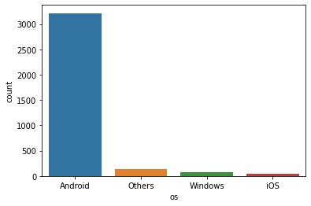

```python
sns.countplot(data=df, x=df['os'], order=df['os'].value_counts(ascending=False).index);
plt.show()
```

- 4 different OS are listed.
- Maximum number of devices run on Android OS.
- Devices running on iOS are the least.
1. Analysing the resolution of the rear camera in megapixels

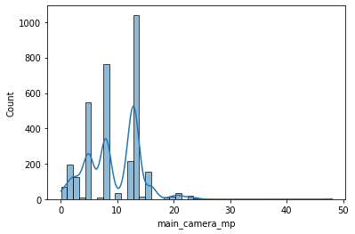

```python
sns.histplot(data=df, x=df['main_camera_mp'], kde=True);
plt.show()
```

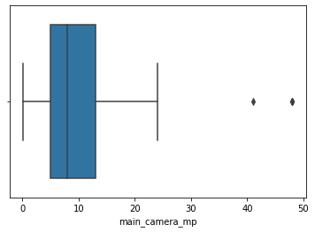

```python
sns.boxplot(data=df, x=df['main_camera_mp']);
plt.show()
```

- We know that 179 values for `main_camera_mp` are missing (marked as nan).
- The boxplot shows some outliers too.
1. Analysing the resolution of the front camera in megapixels

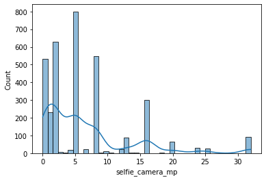

```python
sns.histplot(data=df, x=df['selfie_camera_mp'], kde=True);
plt.show()
```

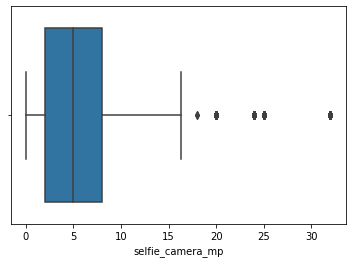

```python
sns.boxplot(data=df, x=df['selfie_camera_mp']);
plt.show()
```

- We know that 2 values for `selfie_camera_mp` are missing (marked as nan).
- The boxplot shows some outliers too.
1. Analysing the amount of internal memory (ROM) in GB

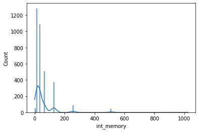

```python
sns.histplot(data=df, x=df['int_memory'], kde=True);
plt.show()
```

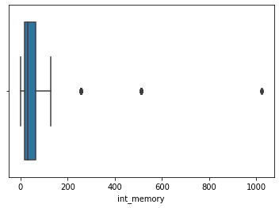

```python
sns.boxplot(data=df, x=df['int_memory']);
plt.show()
```

- We know that 4 values for `int_memory` are missing (marked as nan).
- The boxplot shows some outliers too.
- The plot is right skewed.
1. Analysing the amount of RAM in GB

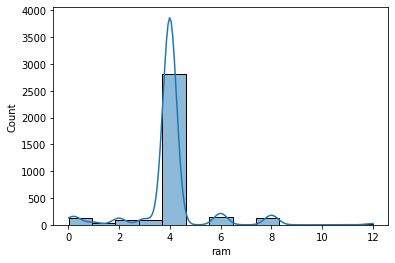

```python
sns.histplot(data=df, x=df['ram'], kde=True);
plt.show()
```

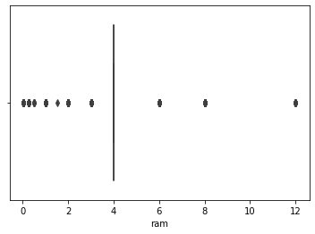

```python
sns.boxplot(data=df, x=df['ram']);
plt.show()
```

- We know that 4 values for `ram` are missing (marked as nan).
- Majority of devices have 4GB RAM.
- The histplot looks almost symmetrical.
- The boxplot doesn't give a clear picture.
1. Analysing the energy capacity of the device battery in mAh

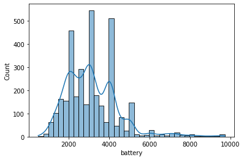

```python
sns.histplot(data=df, x=df['battery'], kde=True);
plt.show()
```

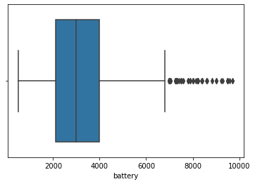

```python
sns.boxplot(data=df, x=df['battery']);
plt.show()
```

- We know that 6 values for `battery` are missing (marked as nan).
- The boxplot shows some outliers.
- Median value for `battery` is about 3000 mAh.
1. Analysing the weight of the device in grams

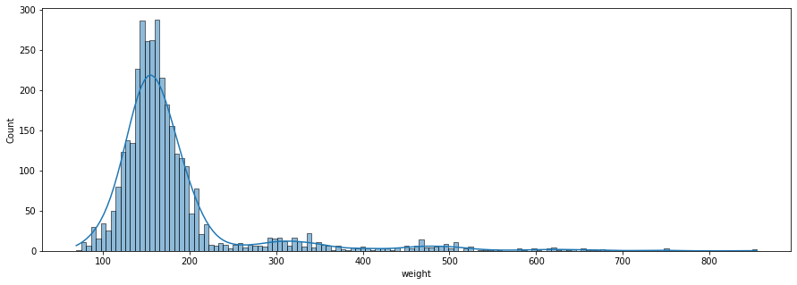

```python
plt.figure(figsize=[15,5])
sns.histplot(data=df, x=df['weight'], kde=True);
plt.show()
```

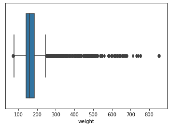

```python
sns.boxplot(data=df, x=df['weight']);
plt.show()
```

- We know that 7 values for `weight` are missing (marked as nan).
- The boxplot shows many outliers.
- Median value for `weight` is about 160 gms.
1. Analysing the release year

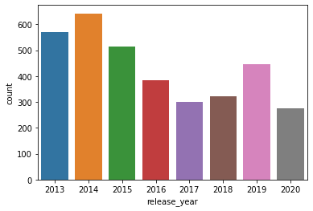

```python
sns.countplot(data=df, x=df['release_year']);
plt.show()
```

- Maximum models were released in the year 2014, followed by 2013.
- Number of models released in the year 2020 is the lowest.
1. Analysing the normalized price of the used/refurbished device in euros

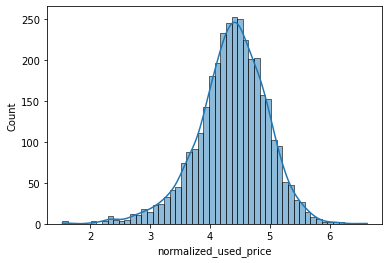

```python
sns.histplot(data=df, x=df['normalized_used_price'], kde=True);
plt.show()
```

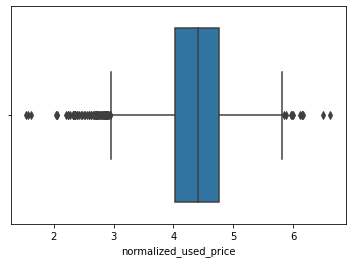

```python
sns.boxplot(data=df, x=df['normalized_used_price']);
plt.show()
```

Qn.1. What does the distribution of normalized used device prices look like?

- The graph for `normalized_used_price` looks like a bell-shaped curve. Hence, we can say that the distribution looks like normal distribution.
- The boxplot shows many outliers.
- The median value of `normalized_used_price` is about 4.4 euros.
1. Analysing the normalized price of a new device of the same model in euros

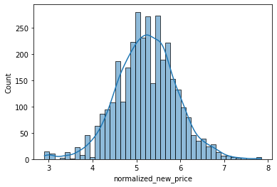

```python
sns.histplot(data=df, x=df['normalized_new_price'], kde=True);
plt.show()
```

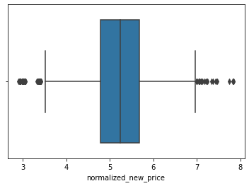

```python
sns.boxplot(data=df, x=df['normalized_new_price']);
plt.show()
```

- The graph for `normalized_new_price` is almost similar to normal curve(bell-shaped).
- The boxplot shows many outliers.
- The median value of `normalized_new_price` is about 5.2 euros.

### Multivariate Analysis

Analysing the correlation between variables

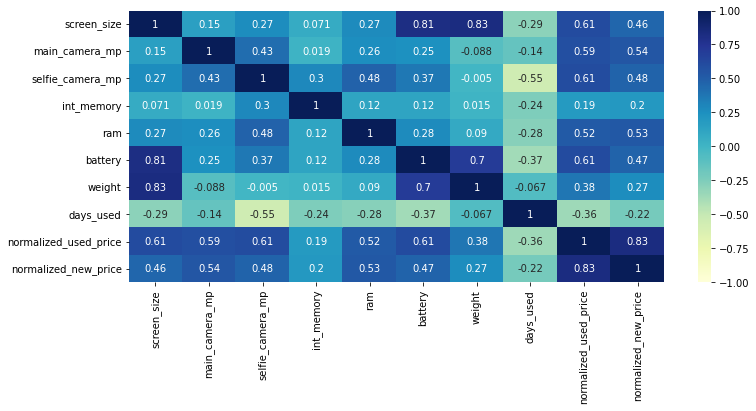

```python
col_list = df.select_dtypes(include=np.number).columns.tolist()
col_list.remove('release_year')

plt.figure(figsize=[12,5])
sns.heatmap(data=df[col_list].corr(), annot=True, vmax=1.0, vmin=-1.0, cmap='YlGnBu');
plt.show()
```

- From the heat map, we see high positive correlation (>0.8) between the variable pairs (`weight` and `screen_size`), (`normalized_used_price` and `normalized_new_price`), (`battery` and `screen_size`).
- (`battery` and `weight`) too have positive correlation (0.7).

Qn.2. What percentage of the used device market is dominated by Android devices?

```python
android_count = df['os'].value_counts()['Android']
total_count = df['os'].value_counts().sum()
perc_android = (android_count/total_count)*100
print(round(perc_android, 2))
```

```
93.05
```

- 93.05% of the used device market is dominated by Android devices.

Qn.3. The amount of RAM is important for the smooth functioning of a device. How does the amount of RAM vary with the brand?

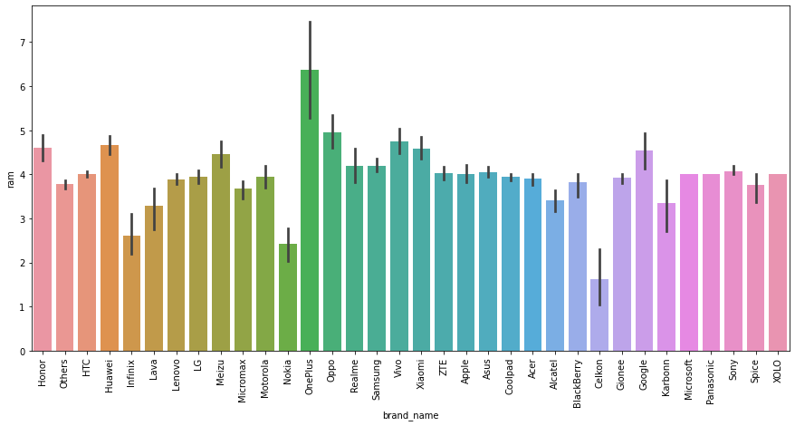

```python
plt.figure(figsize=[15,7])
plt.xticks(rotation=90)
sns.barplot(data=df, x=df['brand_name'], y=df['ram']);
plt.show()
```

- The average amount of RAM for OnePlus is the highest, followed by Oppo.
- The average is lowest for Celkon, followed by Nokia.

Qn.4. A large battery often increases a device's weight, making it feel uncomfortable in the hands. How does the weight vary for phones and tablets offering large batteries (more than 4500 mAh)?

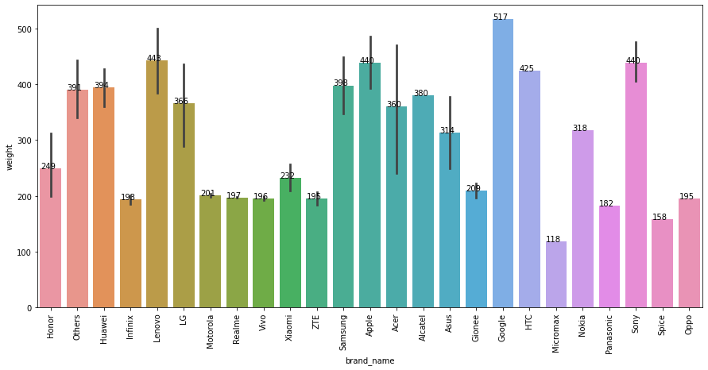

```python
plt.figure(figsize=[15,7])
plt.xticks(rotation=90)
large_batteries_df = df[df['battery']>4500]
plot = sns.barplot(data=large_batteries_df, x='brand_name', y='weight', estimator=np.mean,);
for p in plot.patches:
        plot.annotate('{:.0f}'.format(p.get_height()), (p.get_x()+0.3, p.get_height()), ha='center')
plt.show()
```

- For phones and tablets offering large batteries (more than 4500 mAh), Google is the heaviest, followed by Lenovo.
- Micromax offers the lightest devices with large batteries, followed by Spice.

Qn.5. Bigger screens are desirable for entertainment purposes as they offer a better viewing experience. How many phones and tablets are available across different brands with a screen size larger than 6 inches?

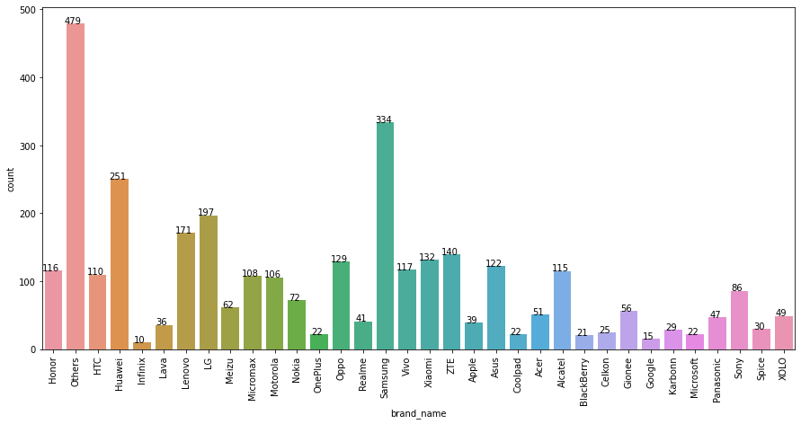

```python
large_screens_df = df[df['screen_size']>6]
plt.figure(figsize=[15,7])
plt.xticks(rotation=90)
plot = sns.countplot(data=large_screens_df, x='brand_name');
for p in plot.patches:
        plot.annotate('{:.0f}'.format(p.get_height()), (p.get_x()+0.3, p.get_height()), ha='center')
plt.show()
```

Qn.6. A lot of devices nowadays offer great selfie cameras, allowing us to capture our favorite moments with loved ones. What is the distribution of devices offering greater than 8MP selfie cameras across brands?

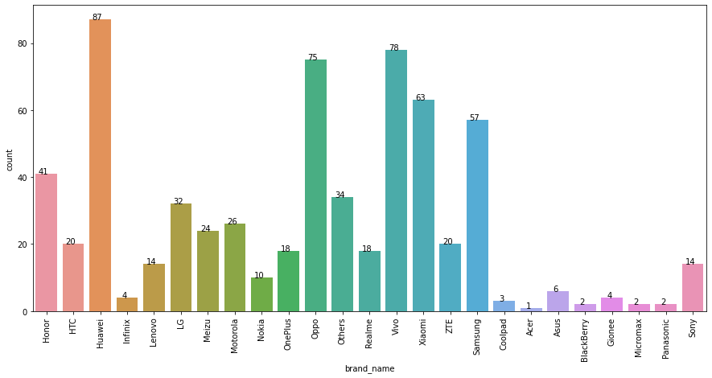

```python
best_selfie_cam_df = df[df['selfie_camera_mp']>8]
plt.figure(figsize=[15,7])
plt.xticks(rotation=90)
plot = sns.countplot(data=best_selfie_cam_df, x='brand_name');
for p in plot.patches:
  plot.annotate('{:.0f}'.format(p.get_height()), (p.get_x()+0.3, p.get_height()), ha='center')
plt.show()
```

- Huawei offers highest number of devices with selfie cameras greater than 8MP, followed by Vivo and Oppo.
- Acer has only one device with selfie camera greater than 8MP, followed by Blackberry, Micromax and Panasonic with two devices each.